# Protocol 1

Joachim Goedhart

2021-12-16

## Protocol 1 - Spectra of fluorescent proteins

This protocol describes how you can turn a csv with spectral data that is obtained from FPbase.org into a plot of those spectra. First, we load the required package:

```r
library(tidyverse)
```

For this data visualization, I selected several spectra from fluorescent proteins at FPbase.org: https://www.fpbase.org/spectra/?s=1746,6551,101,102,123,124,1604,1606&showY=0&showX=1&showGrid=0&areaFill=1&logScale=0&scaleEC=0&scaleQY=0&shareTooltip=1&palette=wavelength

The data was downloaded in CSV format (by clicking on the button in the lower right corner of the webpage) and renamed to ‘FPbase_Spectra_4FPs.csv’. We read the data from the CSV by using the `read_csv()` function. This function is part of the tidy verse and loads the data as a tibble. It also guesses type of data for each column. To hide that information, we use `show_col_types = FALSE` here.

```r
df_spectra <- read_csv("FPbase_Spectra_4FPs.csv", show_col_types = FALSE)
```

Let’s briefly look at what we have loaded:

```r
glimpse(df_spectra)
```

```
## Rows: 512
## Columns: 9
## $ Wavelength       <dbl> 300, 301, 302, 303, 304, 305, 306, 307, 308, 309, 310, 311, 312, 313, 314, 315, 316, …
## $ `mTurquoise2 EM` <dbl> NA, NA, NA, NA, NA, NA, NA, NA, NA, NA, NA, NA, NA, NA, NA, NA, NA, NA, NA, NA, NA, N…
## $ `mTurquoise2 EX` <dbl> 0.2484, 0.2266, 0.2048, 0.1852, 0.1634, 0.1482, 0.1329, 0.1242, 0.1133, 0.1068, 0.098…
## $ `mNeonGreen EM`  <dbl> NA, NA, NA, NA, NA, NA, NA, NA, NA, NA, NA, NA, NA, NA, NA, NA, NA, NA, NA, NA, NA, N…
## $ `mNeonGreen EX`  <dbl> NA, NA, NA, NA, NA, NA, NA, NA, NA, NA, NA, NA, NA, NA, NA, NA, NA, NA, NA, NA, NA, N…
## $ `mScarlet-I EM`  <dbl> NA, NA, NA, NA, NA, NA, NA, NA, NA, NA, NA, NA, NA, NA, NA, NA, NA, NA, NA, NA, NA, N…
## $ `mScarlet-I EX`  <dbl> NA, NA, NA, NA, NA, NA, NA, NA, NA, NA, NA, NA, NA, NA, NA, NA, NA, NA, NA, NA, NA, N…
## $ `miRFP670 EM`    <dbl> NA, NA, NA, NA, NA, NA, NA, NA, NA, NA, NA, NA, NA, NA, NA, NA, NA, NA, NA, NA, NA, N…
## $ `miRFP670 EX`    <dbl> NA, NA, NA, NA, NA, NA, NA, NA, NA, NA, NA, NA, NA, NA, NA, NA, NA, NA, NA, NA, NA, N…
```

The data needs conversion to a tidy format before plotting. Since we have a single continuous data column with Wavelength information that is used for the x-axis, it is excluded from the operation:

```r
df_spectra_tidy <-
  pivot_longer(
    df_spectra,
    cols = -Wavelength,
    names_to = "Sample",
    values_to = "Intensity"
  )
```

There are several rows that have NA values for Intensity and this is how to get rid of that:

```r
df_spectra_tidy <- df_spectra_tidy %>% drop_na(Intensity)
```

The column ‘Sample’ has labels for the fluorescent protein and the type of spectrum. We can separate that column into two different columns that we name ‘Fluorescent Protein’ and ‘Spectrum’:

```r
df_spectra_tidy <- df_spectra_tidy %>%
  separate(Sample, c("Fluorescent Protein", "Spectrum"), sep = " ")
```

Let’s do a first attempt and plot the data:

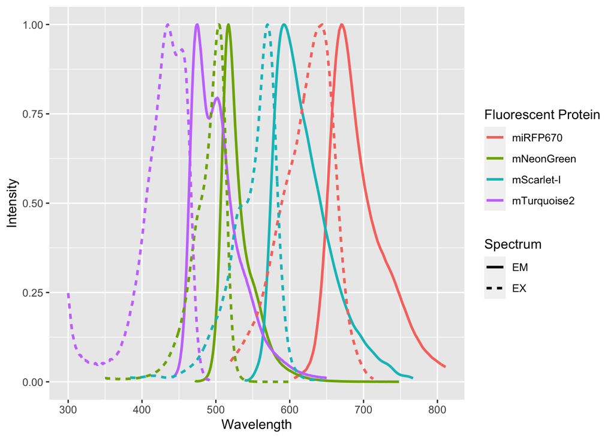

```r
ggplot(
  data = df_spectra_tidy,
  aes(x = Wavelength, y = Intensity, color = `Fluorescent Protein`)
) +
  geom_line(aes(linetype = Spectrum), size = 1)
```

This looks pretty good already. Now let’s change the order of the fluorescent proteins to their order in the plot:

```r
df_spectra_tidy <- df_spectra_tidy %>%
  mutate(`Fluorescent Protein` = forcats::fct_relevel(
    `Fluorescent Protein`,
    c("mTurquoise2", "mNeonGreen", "mScarlet-I", "miRFP670")
  ))
```

We define the plot object and add an extra geometry, `geom_area()` to fill the area under the curves:

```r
p <-
  ggplot(
    data = df_spectra_tidy,
    aes(
      x = Wavelength, y = Intensity,
      fill = `Fluorescent Protein`
    )
  ) +
  geom_line(aes(linetype = Spectrum),
    size = 0.5, alpha = 0.5
  ) +
  geom_area(
    aes(linetype = Spectrum),
    color = NA,
    position = "identity",
    size = 1,
    alpha = 0.5
  )
```

Let’s check the result:

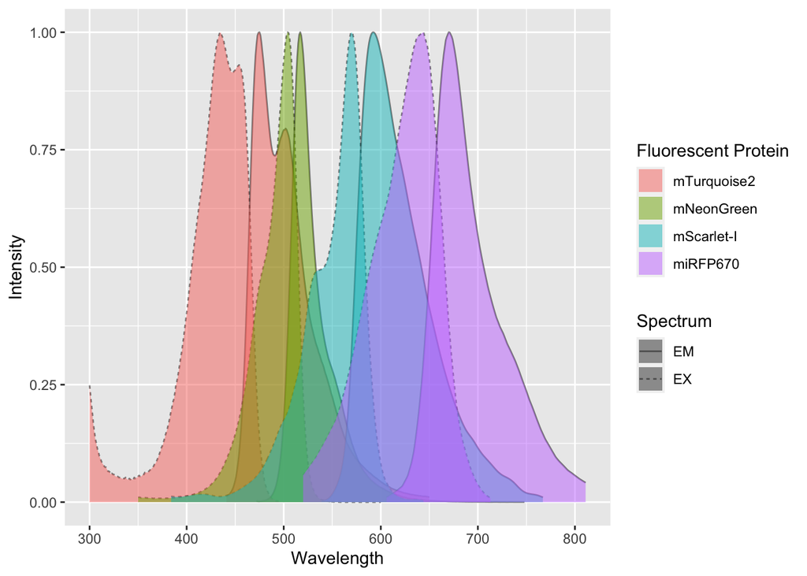

```r
p
```

Next, we set the limits of the axis and force the y-axis to start at 0

```r
p <-
  p + scale_y_continuous(expand = c(0, 0), limits = c(0, 1.1)) +
  scale_x_continuous(expand = c(0,0), limits = c(350, 810))
```

Add labels:

```r
p <-
  p + labs(
    title = "Spectra of Fluorescent Proteins",
    x = "Wavelength [nm]",
    y = "Normalized Intensity [a.u.]",
    caption = "(based on data from FPbase.org)",
    tag = "Protocol 1"
  )
```

Modify the layout by adjusting the theme. Comments are used to explain effect of the individual lines of code:

```r
p <-
  #Set text size
  p + theme_light(base_size = 14) + theme(
    plot.caption = element_text(
      color = "grey80",
      hjust = 1
    ),
    #Remove grid
    panel.grid.major = element_blank(),
    panel.grid.minor = element_blank(),
    #Set position of legend
    legend.position = "top",
    legend.justification = "left"
    #Define the legend layout
  ) + guides(
    linetype = "none",
    fill = guide_legend(title = NULL, label.position = "right")
  )
```

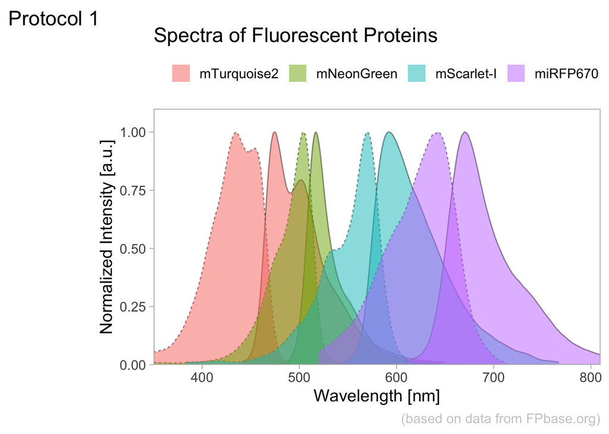

```r
p
```

We are almost there, except that the colors of the plot do not match with the natural colors of the fluorescent proteins. Let’s fix that by defining a custom color palette. The order of the colors matches with the order of the fluorescent proteins that was defined earlier:

```r
custom_colors <- c("blue", "green", "orange", "red")
```

To apply the custom colors to the filled area:

```r
p <- p + scale_fill_manual(values = custom_colors)
```

This is the result:

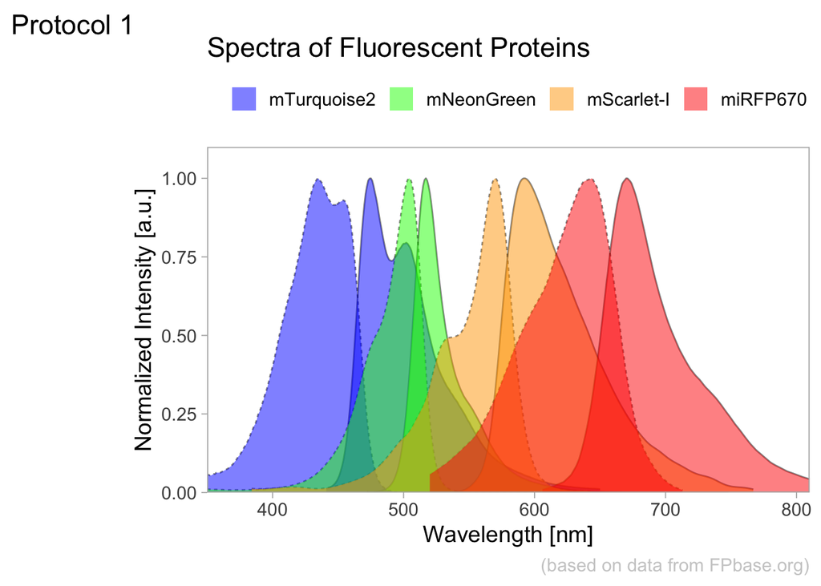

```r
p
```

To save this plot as a PNG file:

```r
png(file=paste0("Protocol_1.png"), width = 4000, height = 2600, units = "px", res = 400)
  p
dev.off()
```